# Better Know a Function – Exploring Logistic Growth

BIO 107

2023-04-07

# What is Due?

1. The first six questions are the assignment sheet are labeled Q1, Q2,.. Q6. The questions are in this worksheet but you need to open the quiz in Brightspace to answer these. These are multiple choice in the Brightspace page. **Do these as you go through the worksheet, not at the end**.
2. The assignment sheet has other questions after the first six, these are for your own growth. The more you stop and think about them, the more you grow. I will address these in lecture.
3. There is an assignment for this lab on brightspace. You may (encouraged!) work in teams and help each other but everyone should have their own Google sheet. Share this with me (walker@maine.edu) **AND** submit the link to the sheet in the assignment on brightspace.

# Motivations

## Motivation number 1: seeing a function in a textbook

$$\frac{\Delta N}{\Delta T} = rN(\frac{K-N}{K})$$

You see this equation in Section 53.3 of your textbook, with a nice explanation of the different parts of the equation. Often, however, there isn’t a good explanation of the parts. And even if there is a good explanation, it is really easy to just give a very perfunctory look at the equation and read of the section (ever since Stephen Jay Gould used “desultory” instead of “perfunctory” in one of his essays, these two words have been a favorite of mine. Desultory means to jump around, as in a conversation. Perfunctory means to do something mindlessly).

A spreadsheet is a wicked valuable learning tool for **self-discovery** of the behavior of a function like this. By **behavior**, I mean what a graph of the function looks like, if we change the parameters (the variables on the right hand side). This activity is an introduction to **self-discovery**.

## Motivation number 2: Quantitative vs. Qualitative Science

Biologists frequently observe population growth and decline in some species, and a major goal in ecology is to discover the mechanisms regulating this growth or decline. For example, if oak trees in southern Maine have a large mast event (dropping lots of acorns), then we might expect an increase in the chipmunk population the next year using the logic that adult chipmunks turn food into babies. But this is all very qualitative. Good science often requires abstracting some specific but qualitative phenomonenon into a general, quantitative model. In this lab, we’re going to **numerical self-discovery** to explore some simple, quantitative models of population size.

# Initial intuitions – Envisioning quantitative functions

Good science often starts with envisioning (picture in their head) the relationship between two variables give a working model of the relationship. Let’s do this.

*Q1* – Think about a lake in Alaska that has been poisoned by Alaska Fish and Game to kill all fish species in the lake. Now Fish and Game introduces a small stock of Rainbow Trout into the lake. What should population growth of rainbow trout in the lake following stocking look like? Think about what the relationship between Fish Count (N) and Years following Introduction (Year) would look like on a graph. Which of the following graphs is the closest to the vision in your mind? (note 2-5% of humans cannot enivision objects in their mind, a condition called afantasia. If you have afantasia, then sketch the graph on a scrap piece of paper instead of envisioning this in your mind).

# The logistic model of population growth

Let’s start with the **logistic model** of population growth. Your textbook presents this equation to you.

$$\frac{\Delta N}{\Delta T} = rN(\frac{K-N}{K})$$

Here we aren’t concerned with deriving the equation or with the assumptions of using this function to model something biological. We are concerned only with the behavior of the function itself. I’ll leave derivation and assumptions to other worksheets.

You see this function in your textbook or on the blackboard. How do you use a spreadsheet to self-discover? That is, how do you get the equation into a spreadsheet?

1. First, be sure to think of this equation as a function similar to a function in a spreadsheet. A function has **inputs** and **outputs**. The parameters $r$, $N$, and $K$ on the right hand side (rhs) of the function are the inputs. $\frac{\Delta N}{\Delta T}$ on the left hand side (lhs) is the output. If you use some specific set of numbers for the inputs, then do the simple math, you get a specific value for the output
2. Second, what is all the stuff in the equation? The parameters on the rhs of the equal sign are
- $r$ is the intrinsic growth rate. We’ll define this better in a minute.
- $N$ is population size, that is the number of individuals
- $K$ is the **equilibrium population size** or “carrying capacity”.

*Q2* – When you come across phrases like “equilibrium population size”, stop for a moment to think about what this means. Which of these responses is closest to what you’re thinking?

The left hand side (lhs) of the equation is the output. The output is just a single number but there are three things on the lhs

- $N$ is defined above
- $T$ is time. The unit of time (minutes, days, generations) isn’t specified and doesn’t matter here.
- $\Delta$ is not a variable it is a symbol meaning “change in” and used to specify how one variable changes given change in another variable. So $\frac{\Delta N}{\Delta T}$, which is read as “delta en over delta tee” is the **change in population size over time**. Any change in something over time is a *rate*, so $\frac{\Delta N}{\Delta T}$ is the rate of population growth.

## Rearrange the equation

In the thought question (Q1) above, I asked you to envision how the population size (N) changes over time. But the logistic function above models the rate of growth, not the population size. So let’s do some algebra on this equation, to model population size as a function of time *if the population is growing logistically*. That is, **we want to create a plot with $N$ on the $y$-axis and $Time$ on the $x$-axis**.

Let’s expand $\Delta N$

$$\Delta N = N_{t+1} - N_t$$

Wait, what is “t” and “t+1”? $t$ is a point in time (any point in time) and $t+1$ is one time unit after time $t$. For example, if $t$ is day 30 and the unit of time is “one day” then $t+1$ is day 31.

So $N_{t+1} - N_t$ is the change in count after a single time step (a day, a month, a year). Here we say that $t$ “indexes time”.

For this assignment, let’s think of $t$ as indexing a generation (the time from parents to offspring). So $\Delta N$ is the change in count over a single generation.

Since the change in time ($\Delta T$) is one unit, this means

$$\frac{\Delta N}{\Delta T} = \frac{N_{t+1} - N_t}{1} = N_{t+1} - N_t$$

Substitute this in to the lhs of the logistic equation

$$N_{t+1} - N_t = rN_t(\frac{K-N_t}{K})$$

and re-arrange …

$$N_{t+1} = N_t +
rN_t(\frac{K-N_t}{K})$$

Now we have a function for the count at any generation. Another, and maybe more useful for mental exploration, way to write this is

$$N_{t+1} = N_t + rN_t(1 -
\frac{N_t}{K})$$
**This is the equation that you want to numerically self-discover with Google sheets**

## Mental Self-Discovery

Let’s think about the parameter on the rhs and how they should effect the output ($N_{t+1}$).

1. First, note that the count at generation $t+1$ is the sum of two things: the count at generation $t$ and some value that is itself a function of the count at generation $t$. Think about this, without any information other than the count, we would expect the count in the next generation to be the count in the previous generation. But if we have more information (the intrinsic growth rate $r$ or the equilibrium population size $K$) then we can refine this expectation.
2. The equilbrium population size $K$ is the size that we would expect the population to be given a certain level of resources (the amount of food, the amount of space for nesting, etc.). How does $K$ modify $N_t$?. Think about this as

$$N_t(1 - \frac{N_t}{K})$$

$K$ is a theoretical population size so its value must be a number between zero and infinity. It can’t really be infinity but its useful to think about what happens if $K$ were infinity. And if there are any resources, it can’t be zero.

**Q3** If $K = \infty$ (“K is infinity”), what is the value of $N_t(1 - \frac{N_t}{K})$?

**Q4** If $K = \infty$, then the logistic growth equation reduces to?

The correct equation is known as the **exponential growth model**. Again, $K$ can never really be infinity but its useful to think of exponential growth as a special case of logistic growth. And that when the population size is far below the equilibrium population size, growth should be effectively exponential.

**Q5** If $K = N_t$, what is the value of $N_t(1 - \frac{N_t}{K})$?

**Q6** If $K = N_t$, then the logistic growth equation reduces to?

Stop and think, does your answer to Q6 make sense?

# Numerical Self-Discovery

Students in Biology are inundated with equations both from Biology classes and from classes such as Physics and Chemistry. For most of us, these equations are pretty hard to really understand, even if we can do the math. By “understand”, I mean, to treat the equation as a function, with inputs (the parameters) and outputs (what the function equates to given the parameters) and to have a picture in one’s head of how this function behaves. By “behave”, I mean what the function looks like and how “what it looks like” depends on the parameters. A spreadsheet is a terrific way to self-discover the behavior of a function. This worksheet is a step-by-step guide on how to do this. The skills learned here should be transferable to any function, although a spreadsheet might not be the perfect tool for some more complex functions.

# Explore the logistic model in a spreadsheet

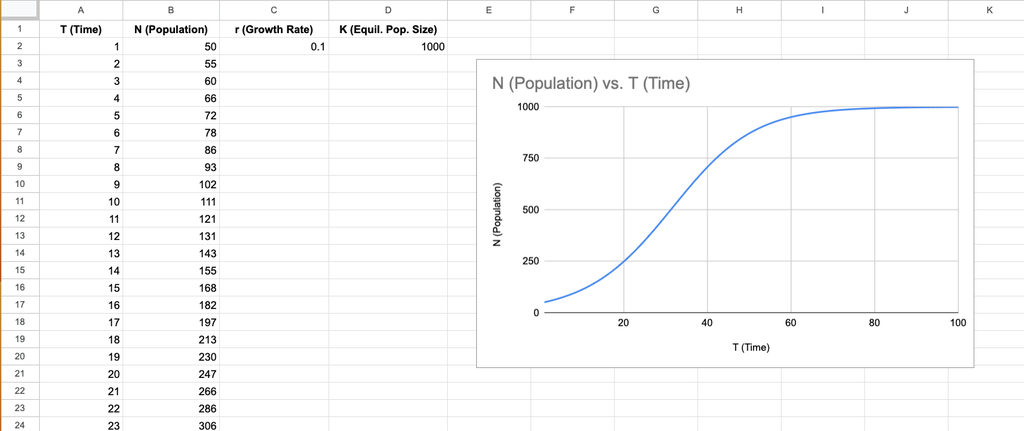

Open Google Sheets.

1. First set up a row of column labels containing all the variables that we care about (see figure above). This includes a column $T$ for $Time$ (or generation) that is not explicitly on the rhs but is there implicitly!
2. **Parameterize the model**. We do this by setting the values of $T$, $N$, $r$ and $K$. I inserted “1” for $T$, “50” for $N$, “.1” for $r$ and “1000” for $K$. Don’t worry about the values you insert because the beauty of using a spreadsheet for self-discovery is that you will change these later!
3. In Cell A3, insert the formula to increase $T$ by 1 unit.
4. In Cell B3, insert the formula for $N_{t+1}$ (N at time 2) as a function of $N_t$ (N at time 1). Use the cell address for the values of $r$ (cell C2) and $K$ (cell D2) in the formula AND use the $ sign to force this formula to point to cells C2 and D2. Use the logistic equation above to create this formula.
5. Fill down (about 100 rows) the formulas in Cell A3 and Cell B3. Make sure that the formula in column B always refers to cells C2 for $r$ and D2 for $K$.

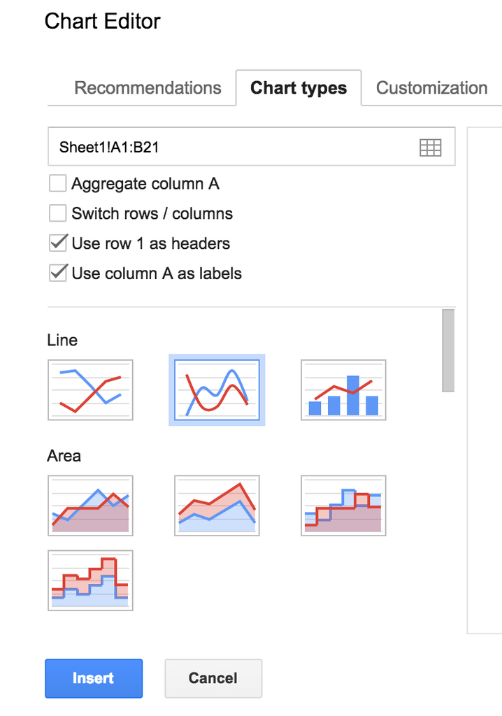

6. Plot the data with $N$ on the y-axis and $Time$ on the x-axis. Click-and-drag to highlight the columns T and N including the labels “T” and “N”. Now choose the menu “Insert Chart” then click on chart type and click the chart highlighted in the figure by the light blue line. Then click “Use column A as labels” which makes the values in the column labeled “T” the x-axis. The column labeled $N$ will be the y-axis. 7. Now you have a plot of the function. Now it’s time to explore the function by changing $r$ or changing $K$ or changing the initial $N$. The plot will immediately re-draw in response to these changes. Explore around then come back to the sections below.

# Stuff to explore

1. Set the initial $T$ to 1, the initial $N$ to 50, $r$ to 0.1, and $K$ to 1000.
2. How does the function change if you set $r$ to .5? What about setting $r$ to -.1? What does it mean if $r$ takes the value -.1?
3. Reset r to 0.1. How does the function change if you set $K$ to something different,
   - say to 5000?
   - Change $K$ to 100 and look at the graph and compare to $K = 1000$ – what’s missing from the graph at $K = 100$?
   - What about to something less than the initial $N$, say 25. Does setting $K$ to something less than the initial $N$ make sense? Think about a scenario that it does. If you cannot, then maybe it doesn’t make sense. Or maybe it does, but you just cannot think of a scenario!
   - can $K$ be a negative value?

# More stuff to explore - discover chaos

A **damped cycle** of population growth.

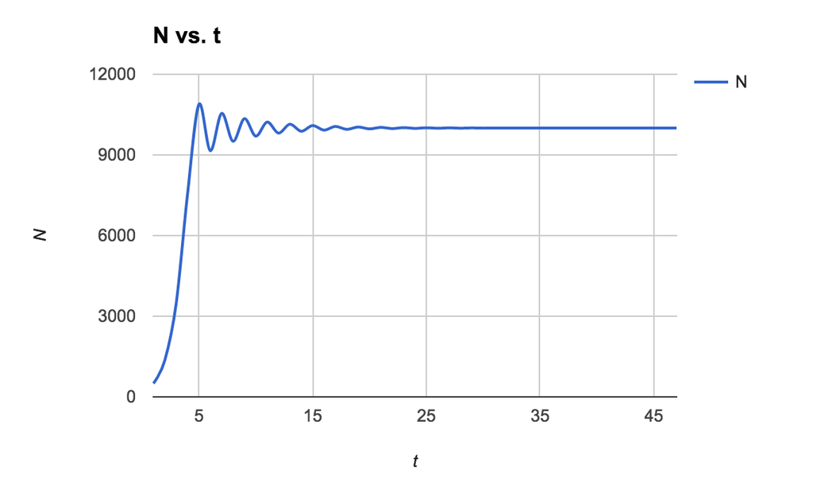

A **stable limit cycle** of population growth.

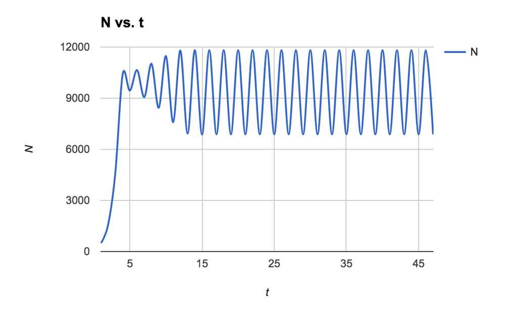

**Chaotic** population growth.

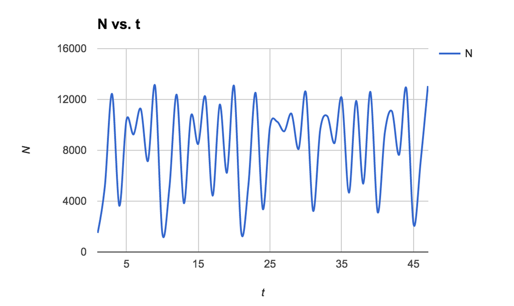

Hint: A damped oscillation occurs if $r$ is between 1 and 2. A stable limit cycle occurs if $r$ is between 2 and 2.69. Chaos occurs if r > 2.69.

This behavior of the logistic function was discovered by Robert May, Baron May of Oxford. Baron May wasn’t always Baron May, he was given the title because of his role as science advisor to the Crown and he earned that role because of his development of quantitative models in Ecology. Not surprisingly, given his math skillz, Baron May has a Ph.D. in physics (and not biology).

# a wee bit more to explore

# yet more stuff to explore

1. Set the initial $T$ to 1, the initial $N$ to 1, $r$ to 0.6, and $K$ to 500.
2. Remember that we started with the function for $\frac{\Delta N}{\Delta T}$
3. Create a column that computes $\frac{\Delta N}{\Delta T}$ for each value of $T$. Hint: you cannot do this for the first row ($T=1$), why?
4. Create a plot with $\frac{\Delta N}{\Delta T}$ on the y-axis and $T$ on the x-axis.
5. How does $\frac{\Delta N}{\Delta T}$ change as time goes by (as $T$ gets bigger)?
6. The answer, $\frac{\Delta N}{\Delta T}$ first increases and then decreases.
7. Why?

# and finally - stochastic models

The models above are deterministic - if the same parameters are entered then $N$ at time $T=20$ or $T=100$ is always precisely the same. Even if the function is chaotic. Real populations are affected by processes that cause $r$ or $K$ to change. For example, a particularly heavy winter causes more deaths so $r$ is smaller or more negative. Or maybe it was a particularly flush year for insect prey so $K$ increases. For any real population, there will effectively be an infinite number of these deterministic processes affecting $r$ or $K$, some in the positive direction and some in the negative direction. Instead of modeling many thousands of deterministic processes affecting $r$ and $K$, we combine them all into a single **random variable** that adds some random amount to $r$ or to $K$ **each time step**. This amount will usually be small but sometimes it will be big. And it will be negative as often as positive. We call this added, random amount **noise**. We don’t care (at this point) about what causes this noise, we just want to see how the population handles **stochastic** change in the parameters. A stochastic model is a model that includes random noise in addition to the deterministic component.

How do you add random noise to the model you’ve built? The noise is added to $r$ or to $K$ so these should change each time step, just like $N$. So now the value for $r$ or $K$ needs a formula. I’ll describe this for $r$. You are on your own for $K$. The function to add random normal noise to $r$ is

$$r_t = \bar{r} + \varepsilon_t$$

$\bar{r}$ is the mean $r$ - it is the value that $r$ will fluctuate around. $\varepsilon_t$ is the added noise. You will add noise from a normal distribution with mean zero (so it will be negative as often as positive) and standard deviation $\sigma$.

1. Highlight the first two rows and insert two rows above these. The header row with the parameter labels should now be in row 3
2. Two cells above “N” insert “Mean”
3. One cell above “N” insert “SD” for standard deviation
4. Two cells above “r” insert some mean value for $r$, say 0.6
5. One cell above “r” insert some value for the standard deviation - the bigger this value the more $r$ can change each step. Try 0.1
6. In the cell for $r$ at the initial time (C4) insert the formula for $r_t$ with added random noise, how do you translate the function into a spreadsheet formula?
7. the answer is “=C$1 + norminv(rand(),0,C$2)”
8. Now copy this formula down for all values of $T$. You should have some variation in $r$ with most values near .6
9. Now you also need to modify your formula for $N$, since it refers only to the value of $r$ at the initial time, how do you do this?
10. Correct! click in cell B5 and remove the dollar sign from “C$4” so that the referred cell “moves down” when copied and pasted
11. Now highlight cell B5 and click and drag the bounding box to the end of your table. The value of $N$ now includes a stochastic component.

And, what to do with your new stochastic model? Remember not to change $r$ by changing the value in cell C4! Instead play around with the Mean and SD. Make the SD as big or bigger than the Mean, either by increasing the SD or making the Mean small. Can you make a population go extinct even though it has a positive mean $r$?